# Usando el GBM

Carlos Nieves

# Paquetes necesarios

```r
set.seed(456)
library(quantmod)
library(moments)
library(tseries)
```

# Descargar datos reales

```r
ticker <- "GFNORTEO.MX"
getSymbols(ticker, scr="yahoo", from="2015-01-01")
```

```
## [1] "GFNORTEO.MX"
```

```r
precio <- na.omit(Ad(get(ticker)))
```

# Precio, log del precio y los rendimientos

```r
log_precio <- log(precio)
simple_rend <- dailyReturn(precio, type="arithmetic")
log_rend <- dailyReturn(precio, type="log")
head(cbind(simple_rend, log_rend, log_precio))
```

```
##            daily.returns daily.returns.1 GFNORTEO.MX.Adjusted
## 2015-01-02   0.000000000     0.000000000             3.727426
## 2015-01-05  -0.028288806    -0.028696645             3.698730
## 2015-01-06  -0.009660555    -0.009707521             3.689022
## 2015-01-07   0.021618906     0.021388532             3.710411
## 2015-01-08   0.015096726     0.014983904             3.725395
## 2015-01-09  -0.008516674    -0.008553148             3.716841
```

# Gráficas

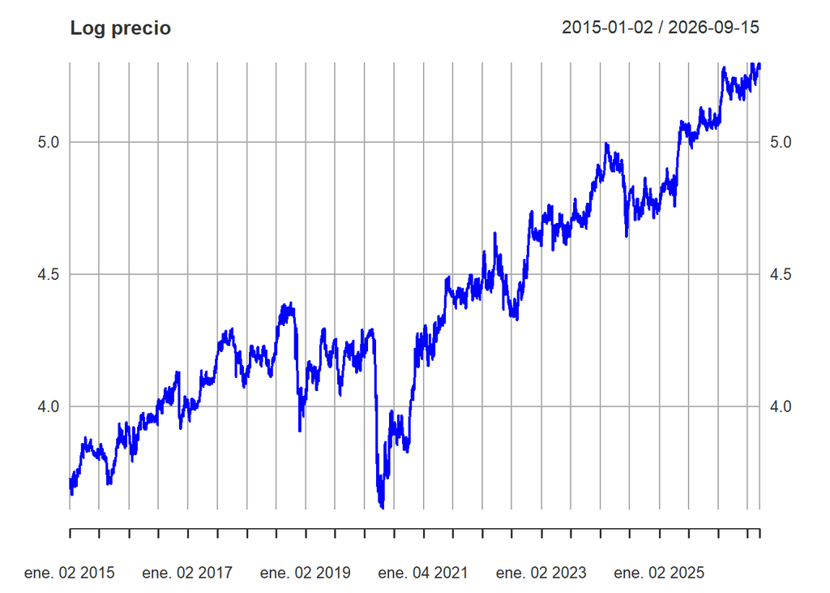

```r
plot(log_precio, main="Log precio", col="blue")
```

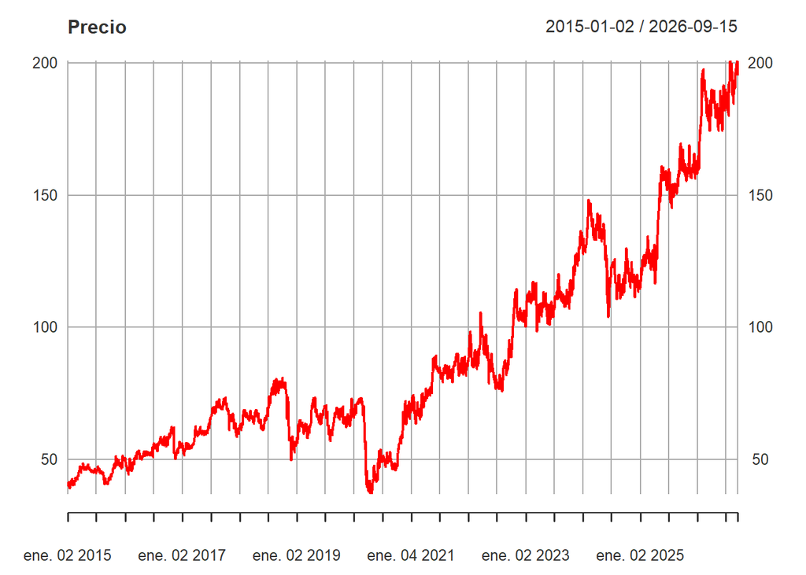

```r
plot(precio, main="Precio", col="red")
```

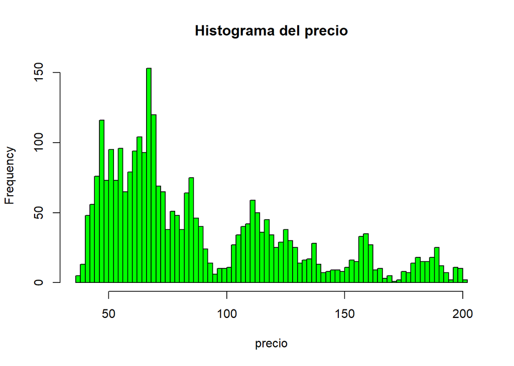

```r
hist(precio, n=100, main="Histograma del precio", col="green")
```

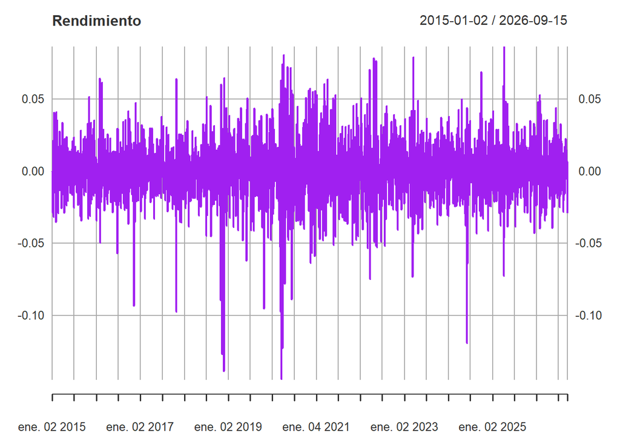

```r
plot(log_rend, n=100, main="Rendimiento", col="purple")
```

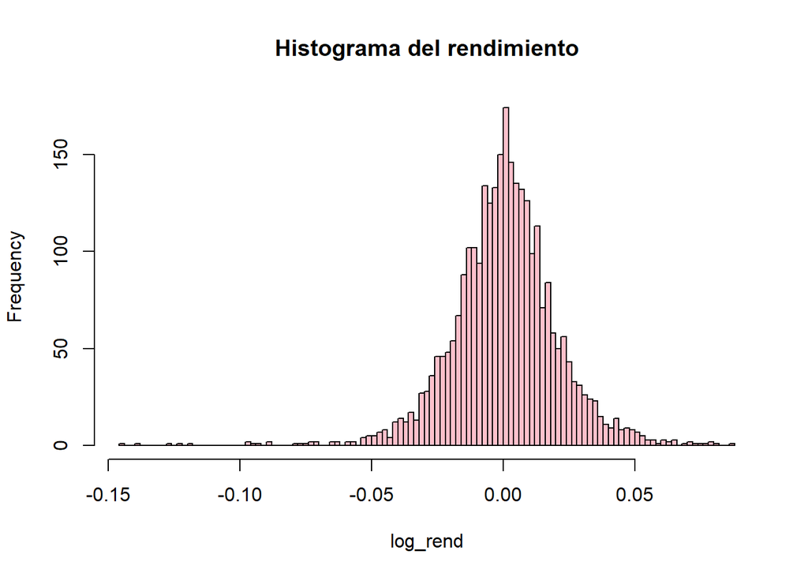

```r
hist(log_rend, n=100, main="Histograma del rendimiento", col="pink")
```

# Media y la volatilidad diaria

```r
r <- mean(log_rend)
R <- mean(simple_rend)
sigma_log <- sd(log_rend)
mean_log <- r
sigma_log
```

```
## [1] 0.02046528
```

```r
mean_log
```

```
## [1] 0.0005255395
```

Pregunta, la media del rendimiento logarítmico, es casi cero. ¿Podemos decir que es estadísticamente igual a cero?

$$Ho: \mu_r=0$$

$$Ha: \mu_r \neq 0$$

```r
t.test(as.numeric(log_rend), mu=0, alternative = "two.sided")
```

```
##
##  One Sample t-test
##
## data:  as.numeric(log_rend)
## t = 1.3929, df = 2941, p-value = 0.1638
## alternative hypothesis: true mean is not equal to 0
## 95 percent confidence interval:
##  -0.0002142758  0.0012653548
## sample estimates:
##    mean of x
## 0.0005255395
```

# ¿Formalmente los rendimientos son normales?

$$Ho: \text{Los datos SI son
normales}$$

$$Ha: \text{Los datos NO son
normales}$$

```r
jarque.bera.test(log_rend)
```

```
##
##  Jarque Bera Test
##
## data:  log_rend
## X-squared = 2484.5, df = 2, p-value < 2.2e-16
```

Rechazamos Ho, entonces los datos de manera formal no siguen un comportamiento de una distribución normal. Esto se puede ver por el sesgo y la curtosis.

```r
kurtosis(log_rend)
```

```
## daily.returns
##      7.387341
```

```r
skewness(log_rend)
```

```
## daily.returns
##    -0.5048375
```

# ¿Qué estima mean(log_ren)?

Aproximadamente estima el valor de:

$$E[r_{\Delta
t}]=(\mu-\frac{1}{2}\sigma^2)\Delta t$$

# ¿Cómo podemos tener una medida de la volatilidad anual?

```r
dias_cot <- 252
sigma_anual <- sigma_log*sqrt(dias_cot)
sigma_anual
```

```
## [1] 0.3248763
```

```r
sigma_log
```

```
## [1] 0.02046528
```

$$\sigma_{anual}=\sigma_{diaria}\sqrt{252}$$

# ¿Por qué por la raíz del tiempo y no solo por el tiempo?

Porque la varianza incrementa de forma más o menos proporcional al tiempo, pero la desviación estándar no.

# Estimar $\mu$

Recordemos que del GBM, tenemos

$$E[r_{\Delta
t}]=(\mu-\frac{1}{2}\sigma^2)\Delta t$$

Entonces despejando

$$\mu=252
r_{diario}+\frac{1}{2}\sigma^2$$

```r
mu_log_anual <- dias_cot*mean_log
mu_log_anual
```

```
## [1] 0.132436
```

```r
mu_gbm_anual <- mu_log_anual+0.5*sigma_anual^2
mu_gbm_anual
```

```
## [1] 0.1852083
```

# ¿Por qué sumamos el $\frac{1}{2}\sigma^2$?

Porque cuando obtenemos el valor esperado de la distribución en logaritmos restamos ese término a la media y debemos por así decirlo regresarlo.

# Comparación con el rendimiento simple

```r
mean_simple_anual <- R*dias_cot
mean_simple_anual
```

```
## [1] 0.1850846
```

# Deben coincidir el promedio de ambas formas de rendimiento?

No, la relación entre el rendimiento simple y logarítmico NO es lineal. Para movimientos pequeños (intervalos cortos) suelen ser cercanos.

# Proyecciones (Definir parámetros)

```r
So <- as.numeric(xts::last(precio))
mu <- mu_gbm_anual
sigma <- sigma_anual
So
```

```
## [1] 195.11
```

```r
mu
```

```
## [1] 0.1852083
```

```r
sigma
```

```
## [1] 0.3248763
```

# Aproximar usando $dS_t$

```r
dt_1d <- 1/dias_cot
mean_ds <- mu*So*dt_1d
sd_ds <- sigma*So*sqrt(dt_1d)
mean_ds
```

```
## [1] 0.1433968
```

```r
sd_ds
```

```
## [1] 3.992981
```

# Simulación con $dS_t$

```r
z <- rnorm(300000, mean = 0, sd=1)
dSt <- mu*So*dt_1d+sigma*So*sqrt(dt_1d)*z
```

Si obtenemos la media de las simulaciones, tenemos que

```r
mean(dSt)
```

```
## [1] 0.1534745
```

```r
sd(dSt)
```

```
## [1] 4.005744
```

# ¿Cuál sería una aproximación al valor del precio?

```r
precio_esp_1d <- So+mean(dSt)
precio_esp_1d
```

```
## [1] 195.2635
```

# ¿Cuál sería un intervalo de confianza al 95% para este precio?

```r
precio_esp_1d+qnorm(.025)*sd_ds
```

```
## [1] 187.4374
```

```r
precio_esp_1d+qnorm(.975)*sd_ds
```

```
## [1] 203.0896
```

# Solución exacta

$$S_T=So
\exp[(\mu-\frac{1}{2}\sigma^2)T+\sigma\sqrt{T}Z]$$

Para 1 día

```r
St_1dia <- So*exp((mu-0.5*sigma^2)*dt_1d+sigma*sqrt(dt_1d)*z)
head(St_1dia)
```

```
## [1] 189.9182 197.7125 198.4385 189.7419 192.3794 193.9222
```

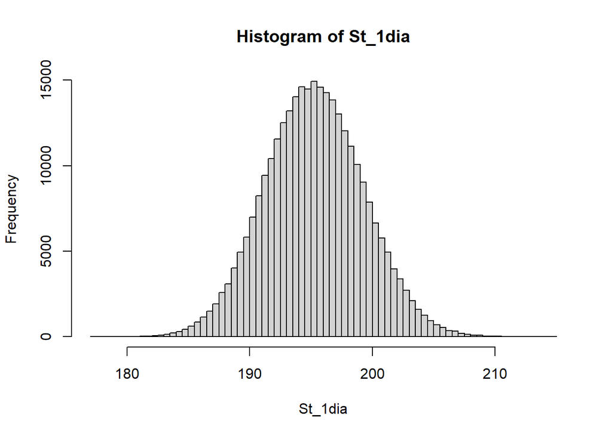

```r
hist(St_1dia, n=100)
```

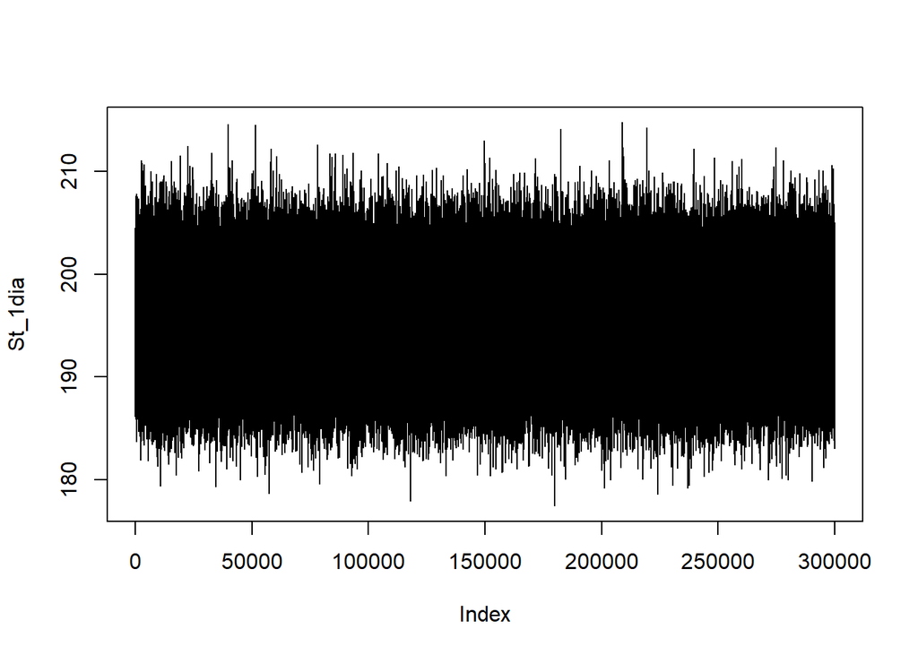

```r
plot(St_1dia, type="l")
```

Estimado del precio para un día

```r
mean(St_1dia)
```

```
## [1] 195.2638
```

Estimado para un mes

```r
dt_1mes <- 20/dias_cot
St_1mes <- So*exp((mu-0.5*sigma^2)*dt_1mes+sigma*sqrt(dt_1mes)*z)
mean(St_1mes)
```

```
## [1] 198.0501
```

Estimado para un año

```r
dt_1ano <- 252/dias_cot
St_1ano <- So*exp((mu-0.5*sigma^2)*dt_1ano+sigma*sqrt(dt_1ano)*z)
mean(St_1ano)
```

```
## [1] 235.0787
```

# Calcular probabilidades usando el precio que hemos simulado

Probabilidad de que el precio en un día supere los 200 MXN

Teórica

```r
e_lnS <- log(So)+(mu-0.5*sigma^2)*dt_1d
ds_lnS <- sigma*dt_1d
e_lnS
```

```
## [1] 5.274089
```

```r
ds_lnS
```

```
## [1] 0.001289192
```

```r
zo <- (log(200)-e_lnS)/ds_lnS
zo
```

```
## [1] 18.79342
```

```r
1-pnorm(zo, mean=0, sd=1)
```

```
## [1] 0
```

```r
pnorm(zo, mean=0, sd=1, lower.tail = FALSE)
```

```
## [1] 4.274353e-79
```

Empírica

```r
mean(St_1dia>200)
```

```
## [1] 0.1194867
```

Probabilidad de que el precio en un mes, disminuya

Empíricamente

```r
mean(St_1mes < So)
```

```
## [1] 0.4539233
```

# Efectuar simulaciones para diferentes puntos del tiempo, usando la solución exacta

```r
head(St_1dia)
```

```
## [1] 189.9182 197.7125 198.4385 189.7419 192.3794 193.9222
```

```r
head(St_1ano)
```

```
## [1] 143.9579 272.5984 288.9301 141.8516 176.6061 200.4810
```

```r
dt_10dia <- 10/dias_cot
St_10dia <- So*exp((mu-0.5*sigma^2)*dt_1mes+sigma*sqrt(dt_1mes)*z)
```

Para cada uno de estos momentos en el tiempo, debemos obtener el valor esperado, el valor mediano y un intervalo de confianza digamos al 95%. Todo esto partiendo de lo que conocemos teóricamente.

Para facilitar este cálculo, haremos una función

```r
gbm_summary <- function(So, mu, sigma, T, nc){
  z_nc=qnorm(1-(1-nc)/2)
  c(
    Precio_Esperado=So*exp(mu*T),
  Mediana=So*exp((mu-0.5*sigma^2)*T),
  Moda=So*exp((mu-0.5*3*sigma^2)*T),
  inferior=So*exp((mu-0.5*sigma^2)*T-z_nc*sigma*sqrt(T)),
  superior=So*exp((mu-0.5*sigma^2)*T+z_nc*sigma*sqrt(T))
  )
}
```

El resumen del precio para 1 día es:

```r
gbm_summary(So, mu, sigma, dt_1d, 0.95)
```

```
## Precio_Esperado         Mediana            Moda        inferior        superior
##        195.2535        195.2126        195.1308        187.5373        203.2019
```

El resumen del precio para 10 días es:

```r
gbm_summary(So, mu, sigma, dt_10dia, 0.95)
```

```
## Precio_Esperado         Mediana            Moda        inferior        superior
##        196.5493        196.1381        195.3183        172.7726        222.6635
```

En un año:

```r
gbm_summary(So, mu, sigma, dt_1ano, 0.95)
```

```
## Precio_Esperado         Mediana            Moda        inferior        superior
##        234.8088        222.7387        200.4280        117.8313        421.0474
```

Verificar los momentos teóricos del comportamiento del precio, consideremos el caso de un año. Definimos 2 momentos, el primero (el valor esperado) y el segundo momento que es la varianza

```r
media_teo <- So*exp(mu*1)
varianza_teo <- So^2*exp(2*mu*1)*(exp(sigma^2*1)-1)
media_emp <- mean(St_1ano)
varianza_emp <- var(St_1ano)
rbind(Simulado=c(Media=media_emp,
      Varianza=varianza_emp),
Teórico=c(Media=media_teo,
          Varianza=varianza_teo))
```

```
##             Media Varianza
## Simulado 235.0787 6188.802
## Teórico  234.8088 6137.412
```

¿Por qué no son iguales? Porque hay un error de montecarlo (el atribuible a la simulación).

¿Cómo mejoramos la simulación? Haciendo más simulación

Cada simulación, es decir cada posible valor de S que está en los objetos St_1d, St_1ano, etc corresponde a un posible valor del precio en ese momento. NO SE TRATA DE UNA TRAYECTORIA DE PRECIO

Vamos a construir una trayectoria para un año.

Usaremos ambas ideas, la aproximación con ds y la solución exacta

```r
z2 <- rnorm(252)
n_dias <- 252
dt <- 1/n_dias
S_exacta <- numeric(n_dias+1)
S_apro <- numeric(n_dias+1)
S_exacta[1] <- So
S_apro[1] <- So
for (i in 1:n_dias){
  S_exacta[i+1] <- S_exacta[i]*exp((mu-0.5*sigma^2)*dt+sigma*sqrt(dt)*z2[i])
  S_apro[i+1] <- S_apro[i]+S_apro[i]*mu*dt+sigma*S_apro[i]*sqrt(dt)*z2[i]
}

S_exacta <- S_exacta
```

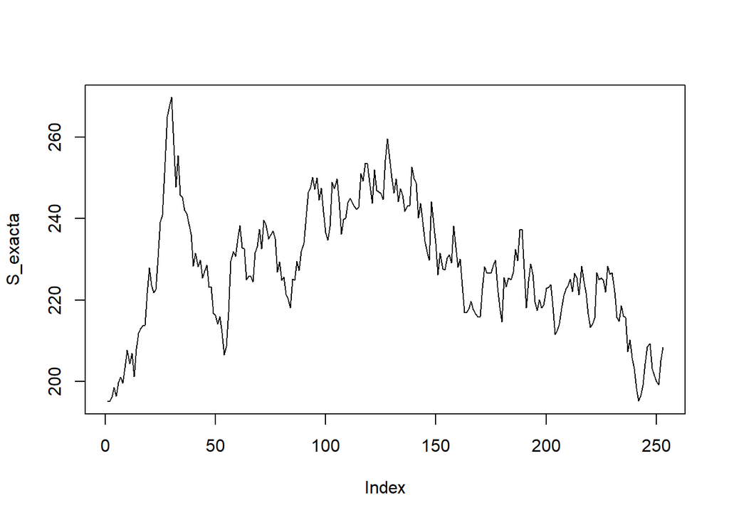

```r
plot(S_exacta, type = "l")
```

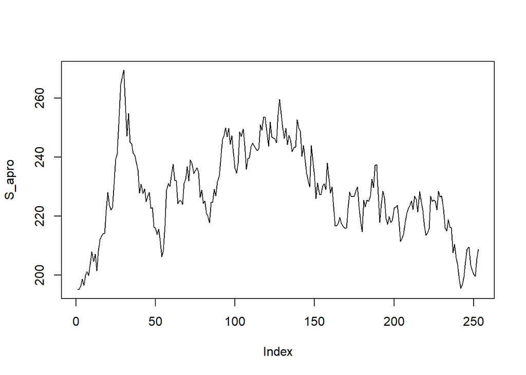

```r
plot(S_apro, type = "l")
```

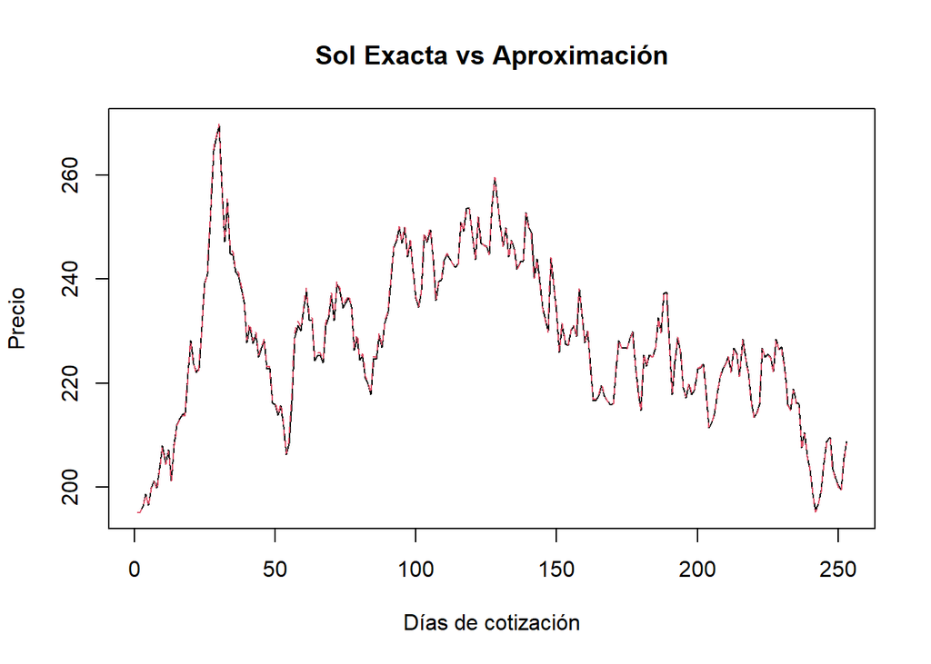

```r
matplot(cbind(S_apro, S_exacta), type = "l", xlab = "Días de cotización", ylab = "Precio", main = "Sol Exacta vs Aproximación")
```